# Assignment-3_QMM_811289717

SAKSHI

2023-10-03

## Problem Statement

Heart Start produces automated external defibrillators (AEDs) in each of three different plants(A, B and C). The unit production costs and monthly production capacity of the two plants are indicated in the table below. The AEDs are sold through three wholesalers. The shipping cost from each plant to the warehouse of each wholesaler along with the monthly demand from each wholesaler are also indicated in the table. How many AEDs should be produced in each plant,and how should they be distributed to each of the three wholesaler warehouses so as to minimize the combined cost of production and shipping?

```r
table.df <- data.frame(WH_1=c("$20","$12","$10",80),
                 WH_2=c("$14","$15","$12",90),
                 WH_3=c("$25","$14","$15",70),
                 Dummy_WH=c(0,0,0,135),
                 Unit_Prod_Cost=c("$400","$300","$500","$1200"),
                 Monthly_Prod_Capacity=c(100,125,150,375))
row.names(table.df)=c("Plant_A","Plant_B","Plant_C","Monthly_Demand")
table.df %>%
  kable() %>%
  kable_classic() %>%
  column_spec(2,border_left = TRUE) %>%
  column_spec(6,border_left = TRUE) %>%
  row_spec(3,extra_css = "border-bottom:dotted;") %>%
  add_header_above(c(" " = 1, "Unit Shipping Cost" = 4," "=2))
```

|  | Unit Shipping Cost WH_1 | Unit Shipping Cost WH_2 | Unit Shipping Cost WH_3 | Unit Shipping Cost Dummy_WH | Unit_Prod_Cost | Monthly_Prod_Capacity |
| --- | --- | --- | --- | --- | --- | --- |
| Plant_A | $20 | $14 | $25 | 0 | $400 | 100 |
| Plant_B | $12 | $15 | $14 | 0 | $300 | 125 |
| Plant_C | $10 | $12 | $15 | 0 | $500 | 150 |
| Monthly_Demand | 80 | 90 | 70 | 135 | $1200 | 375 |

1. Formulate and solve this transportation problem using R
2. Formulate the dual of this transportation problem
3. Make an economic interpretation of the dual

In this transportation problem, demand quantity is less than the supply. To solve this unbalanced transportation problem, first we need to convert it into the balanced one by creating the dummy variable. We have demand less than the supply, so we created a dummy demand (a dummy column) with zero transportation cost and dummy demand quantity. After creating a dummy demand, the transportation problem is now looks like Now, demand = supply = 375. It is balanced one.

**Graphical representation of all possible routes to supply from three plants to four warehouses.**

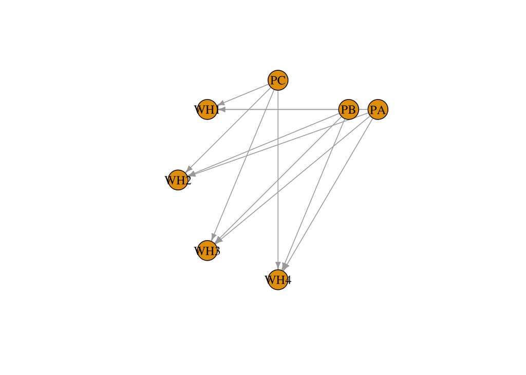

```r
library(igraph)
# Defining the sources, destinations, and their respective supply and demand

sources <- c("PA", "PB", "PC")
supply <- c(100, 125, 150)
destinations <- c("WH1", "WH2", "WH3", "WH4")
demand <- c(80, 90, 70, 135)

# Creating an empty graph with the total number of vertices

total_vertices <- length(sources) + length(destinations)
g <- graph.empty(n = total_vertices, directed = TRUE)

# Adding vertices for sources and destinations

V(g)$name <- c(sources, destinations)

# Creating edges from each source to each destination
for (i in 1:length(sources)) {
for (j in 1:length(destinations)) {
weight <- min(supply[i], demand[j])
if (weight > 0) {
      g <- add_edges(g, edges = c(sources[i], destinations[j]), weight = weight)
}
}
}

# Defining a layout with x-coordinates for sources and destinations

layout <- layout_in_circle(g, order = c(1, 2, 3, 4, 5, 6, 7, 8))

# Plotting the graph with directed edges and the custom layout

plot(g, layout = layout, vertex.label.color = "black", vertex.size = 20, edge.arrow.size = 0.5)
```

## 1.We are going to formulate the transportation model using the above information.

**Identifying the decision variables.**

Let the number of AEDs produced by Plant_A in different warehouses be :

$$Warehouse \hspace{.1cm}1:
x_{11}$$
$$Warehouse \hspace{.1cm}2:
x_{12}$$
$$Warehouse \hspace{.1cm}3:
x_{13}$$
$$Dummy \hspace{.1cm}
Warehouse \hspace{.1cm}: x_{14}$$

Let the number of AEDs produced by Plant_B in different warehouses be :

$$Warehouse \hspace{.1cm}1:
x_{21}$$
$$Warehouse \hspace{.1cm}2:
x_{22}$$
$$Warehouse \hspace{.1cm}3:
x_{23}$$
$$Dummy \hspace{.1cm}
Warehouse \hspace{.1cm}: x_{24}$$

Let the number of AEDs produced by Plant_C in different warehouses be :

$$Warehouse \hspace{.1cm}1:
x_{31}$$
$$Warehouse \hspace{.1cm}2:
x_{32}$$
$$Warehouse \hspace{.1cm}3:
x_{33}$$
$$Dummy \hspace{.1cm}
Warehouse \hspace{.1cm}: x_{34}$$

Hence, the decision variables are -
$$x_{11},x_{12},x_{13},x_{14}\\
x_{21},x_{22},x_{23},x_{24}\\
x_{31},x_{32},x_{33},x_{34}$$

**The objective function can be represented as sum of production and shipping costs:**

$$Z=420x_{11}+414x_{12}+425x_{13}\\
+312x_{21}+315x_{22}+314x_{23}\\
+510x_{31}+512x_{32}+515x_{33}$$
Where each x_{ij} represents the amount of shipment from the source i to the destination j for i=1,2,3 and j=1,2,3,4.

Following are the constraints for this problem-

**Let the Supply constraint be**

From Plant A:

$$Plant
\hspace{.1cm}A:x_{11}+x_{12}+x_{13}+x_{14}\le100$$

From Plant B:

$$Plant
\hspace{.1cm}B:x_{21}+x_{22}+x_{23}+x_{24}\le125$$

From Plant C:

$$Plant
\hspace{.1cm}C:x_{31}+x_{32}+x_{33}+x_{34}\le150$$

**Let the Demand constraint be:**

From Warehouse 1:

$$Warehouse
\hspace{.1cm}1:x_{11}+x_{21}+x_{31}\ge80$$

From Warehouse 2:

$$Warehouse
\hspace{.1cm}2:x_{12}+x_{22}+x_{32}\ge90$$

From Warehouse 3:

$$Warehouse
\hspace{.1cm}3:x_{13}+x_{23}+x_{33}\ge70$$

**Let the Non-negativity of variables be:**

$$x_{ij}\ge0\hspace{0.1cm}where\hspace{0.1cm}i=1,2,3\hspace{0.1cm}and\hspace{0.1cm}j=1,2,3,4$$

**Using lptransport command to solve the equation-**

```r
library(lpSolve)

#Making cost matrix for the equation:

cost.df=matrix(c(420,414,425,0,
                  312,315,314,0,
                  510,512,515,0),nrow = 3,byrow = TRUE)

#Defining signs for supply constraints:

row.signs=rep("<=",3)

#Defining RHS values for supply constraints:

row.rhs=c(100,125,150)

#Defining signs for demand constraints:

col.signs=rep(">=",4)

#Defining RHS values for demand constraints:

col.rhs=c(80,90,70,135)

#Using lptransport command to solve the equation.

optimumsolution=lp.transport(cost.df,"min",row.signs,row.rhs,col.signs,col.rhs)
```

The value of minimized cost is:

```r
optimumsolution$objval
```

```
[1] 88250
```

Solutions of the problem are:

```r
optimumsolution$solution
```

```
     [,1] [,2] [,3] [,4]
[1,]   10   90    0    0
[2,]   55    0   70    0
[3,]   15    0    0  135
```

Out of 12 decision variables, we got 6 of them non-zero. From the solution of the decision variables, we can deduce that Plant A allocates its total supply 100 into two different warehouses: warehouse 1 and 2. Similarly, Plant B supplies its output into warehouses 1 and 3. Plant C sells its output to warehouses 1 and 4. Regarding the demand side, Warehouse 1 is the only place where supply is made from all three suppliers.

Number of AEDs to be produced by Plant_A:

```r
optimumsolution$solution[1,1]+optimumsolution$solution[1,2]+optimumsolution$solution[1,3]+optimumsolution$solution[1,4]
```

```
[1] 100
```

Number of AEDs to be produced by Plant_B:

```r
optimumsolution$solution[2,1]+optimumsolution$solution[2,2]+optimumsolution$solution[2,3]+optimumsolution$solution[2,4]
```

```
[1] 125
```

Number of AEDs to be produced by Plant_C:

```r
optimumsolution$solution[3,1]+optimumsolution$solution[3,2]+optimumsolution$solution[3,3]+optimumsolution$solution[3,4]
```

```
[1] 150
```

## 2.Formulate the dual of this transportation problem.

**Formulating the dual linear equation for this problem.**

Let y and z be the dual variables associated to the two classes of constraints: supply and demand constraints. The constants of the right hand side of the primal will be the coefficients of the objective function of the dual. RHS constants of the primal are 100,125,150,80,90,and 70. So, these numbers will serve as the coefficients of the objective function of the dual.

**Objective function of the dual is**
$$Max \hspace{0.1cm}Z =
80v_{1}+90v_{2}+70v_{3}-100u_{1}-125u_{2}-150u_{3}$$

We already know the values of u1 , u2 and u3 since they are nothing but just the production cost derived from plant A, B and C. u1 = 400 u2 = 300 u3 = 500

**Revised Objective function of the dual is**

$$Max \hspace{0.1cm}Z =
80v_{1}+90v_{2}+70v_{3}-152500$$

**Constraints of the dual problem will be**

$$v_j\ge u_i+TC_{ij}$$
where, TC is the transportation cost.

Plant A delivers output to 3 possible warehouses-

$$v_1\ge400+20=420$$
$$v_2\ge400+14=414$$
$$v_3\ge400+25=425$$

Plant B delivers output to 3 possible warehouses-

$$v_1\ge300+12=312$$
$$v_2\ge300+15=315$$
$$v_3\ge300+14=314$$

Plant C delivers output to 3 possible warehouses-

$$v_1\ge500+10=510$$
$$v_2\ge500+12=512$$
$$v_3\ge500+15=515$$

where
$$v_j \ge \hspace{0.1cm}0
\hspace{0.1cm}and \hspace{0.1cm}j=1,2,3,4$$

## Q-3:Make an economic interpretation of the dual.

Economic interpretation of the problem can be made in following two ways-

**1. MR>=MC**

If we look at our very first constraint which is *v1 >= 420*. Here, v1 represents the revenue generated by one unit of product from Warehouse 1 which can also be called as **Marginal Revenue**(MR). Also, 420 here is the total cost of producing and shipping one unit of product which can also be called as **Marginal Cost**(MC).

To summarize, constraints simply indicate that *MR >= MC*.This means that supplier could increase the production of product from Plant A and shipment to warehouse-1 as long as *MR >= 420*. Similarly, the supplier could decrease production of Product A and shipment to warehouse-1 as long as *MR <= 420*.However, if *v1 = 420* ,i.e, *MR = MC*, the supplier neither increases or decreases production because that’s the optimum situation. This point is called **equilibrium for profit maximization**. Therefore, transportation cost minimization problem is equivalent to its dual profit maximization and both end on the point *MR = MC*.

**2. Hiring and not hiring shipping companies for goods**

If
$$v_{j}>=u_i+TC_{ij}$$
, then supplier will prefer transporting good by himself because the revenue per unit is higher than the transportation cost per unit. However, if
$$v_{j}<=u_i+TC_{ij}$$
_ij then supplier would prefer to hire a shipping company which could transport goods in a cheaper way since they are more specialized than the supplier and supplier will have unit transportation cost higher than the unit revenue. The shipment company would be able to satisfy >= instead of <=.

So, if
$$v_{j} >= u_i+TC_{ij}$$
then supplier and shipper are same but if
$$v_{j}<= u_i+TC_{ij}$$
then supplier prefers hiring a shipper company to reduce its transportation cost.